# Assignment-2

### Propulsion dataset

#### Models for predicting -

1) GT Compressor decay state coefficient  
2) GT Turbine decay state coefficient  
It is assumed that while predicting one of these factors, the other is available as input, for example, while predicting GT Compressor decay state coefficient, GT Turbine decay state coefficient is available as input to our modela and vice versa

```python
#Importing the libraries
import pandas as pd
import numpy as np
import matplotlib.pyplot as plt
import seaborn as sns

data = pd.read_csv("D://Data/propulsion.csv")
data.head()
```

|  | Unnamed: 0 | Lever position (lp) [ ] | Ship speed (v) [knots] | Gas Turbine shaft torque (GTT) [kN m] | Gas Turbine rate of revolutions (GTn) [rpm] | Gas Generator rate of revolutions (GGn) [rpm] | Starboard Propeller Torque (Ts) [kN] | Port Propeller Torque (Tp) [kN] | HP Turbine exit temperature (T48) [C] | GT Compressor inlet air temperature (T1) [C] | GT Compressor outlet air temperature (T2) [C] | HP Turbine exit pressure (P48) [bar] | GT Compressor inlet air pressure (P1) [bar] | GT Compressor outlet air pressure (P2) [bar] | Gas Turbine exhaust gas pressure (Pexh) [bar] | Turbine Injecton Control (TIC) [%] | Fuel flow (mf) [kg/s] | GT Compressor decay state coefficient. | GT Turbine decay state coefficient. |
| --- | --- | --- | --- | --- | --- | --- | --- | --- | --- | --- | --- | --- | --- | --- | --- | --- | --- | --- | --- |
| 0 | 0 | 9.300 | 27.0 | 72762.205 | 3560.393 | 9753.812 | 644.806 | 644.806 | 1086.583 | 288.0 | 780.304 | 4.523 | 0.998 | 22.879 | 1.050 | 90.435 | 1.790 | 0.973 | 0.978 |
| 1 | 1 | 6.175 | 18.0 | 29760.552 | 2306.825 | 8780.012 | 246.011 | 246.011 | 776.921 | 288.0 | 665.511 | 2.518 | 0.998 | 13.438 | 1.030 | 34.596 | 0.685 | 0.995 | 0.975 |
| 2 | 2 | 3.144 | 9.0 | 8375.774 | 1386.739 | 7051.621 | 60.318 | 60.318 | 589.764 | 288.0 | 580.587 | 1.392 | 0.998 | 7.566 | 1.020 | 12.477 | 0.247 | 0.980 | 0.978 |
| 3 | 3 | 3.144 | 9.0 | 8377.589 | 1386.748 | 7098.469 | 60.339 | 60.339 | 570.651 | 288.0 | 576.565 | 1.390 | 0.998 | 7.409 | 1.021 | 11.678 | 0.231 | 0.984 | 1.000 |
| 4 | 4 | 6.175 | 18.0 | 29761.091 | 2306.825 | 8782.024 | 246.021 | 246.021 | 769.855 | 288.0 | 663.682 | 2.518 | 0.998 | 13.374 | 1.031 | 34.154 | 0.676 | 0.998 | 0.980 |

```python
data.info()
```

```
<class 'pandas.core.frame.DataFrame'>
RangeIndex: 10000 entries, 0 to 9999
Data columns (total 19 columns):
 #   Column                                         Non-Null Count  Dtype
---  ------                                         --------------  -----
 0   Unnamed: 0                                     10000 non-null  int64
 1   Lever position (lp) [ ]                        10000 non-null  float64
 2   Ship speed (v) [knots]                         10000 non-null  float64
 3   Gas Turbine shaft torque (GTT) [kN m]          10000 non-null  float64
 4   Gas Turbine rate of revolutions (GTn) [rpm]    10000 non-null  float64
 5   Gas Generator rate of revolutions (GGn) [rpm]  10000 non-null  float64
 6   Starboard Propeller Torque (Ts) [kN]           10000 non-null  float64
 7   Port Propeller Torque (Tp) [kN]                10000 non-null  float64
 8   HP Turbine exit temperature (T48) [C]          10000 non-null  float64
 9   GT Compressor inlet air temperature (T1) [C]   10000 non-null  float64
 10  GT Compressor outlet air temperature (T2) [C]  10000 non-null  float64
 11  HP Turbine exit pressure (P48) [bar]           10000 non-null  float64
 12  GT Compressor inlet air pressure (P1) [bar]    10000 non-null  float64
 13  GT Compressor outlet air pressure (P2) [bar]   10000 non-null  float64
 14  Gas Turbine exhaust gas pressure (Pexh) [bar]  10000 non-null  float64
 15  Turbine Injecton Control (TIC) [%]             10000 non-null  float64
 16  Fuel flow (mf) [kg/s]                          10000 non-null  float64
 17  GT Compressor decay state coefficient.         10000 non-null  float64
 18  GT Turbine decay state coefficient.            10000 non-null  float64
dtypes: float64(18), int64(1)
memory usage: 1.4 MB
```

```python
data.isnull().sum()
```

```
Unnamed: 0                                       0
Lever position (lp) [ ]                          0
Ship speed (v) [knots]                           0
Gas Turbine shaft torque (GTT) [kN m]            0
Gas Turbine rate of revolutions (GTn) [rpm]      0
Gas Generator rate of revolutions (GGn) [rpm]    0
Starboard Propeller Torque (Ts) [kN]             0
Port Propeller Torque (Tp) [kN]                  0
HP Turbine exit temperature (T48) [C]            0
GT Compressor inlet air temperature (T1) [C]     0
GT Compressor outlet air temperature (T2) [C]    0
HP Turbine exit pressure (P48) [bar]             0
GT Compressor inlet air pressure (P1) [bar]      0
GT Compressor outlet air pressure (P2) [bar]     0
Gas Turbine exhaust gas pressure (Pexh) [bar]    0
Turbine Injecton Control (TIC) [%]               0
Fuel flow (mf) [kg/s]                            0
GT Compressor decay state coefficient.           0
GT Turbine decay state coefficient.              0
dtype: int64
```

```python
data.drop(["Unnamed: 0"],axis = 1, inplace = True)
```

```python
data.columns
```

```
Index(['Lever position (lp) [ ]', 'Ship speed (v) [knots]',
       'Gas Turbine shaft torque (GTT) [kN m]',
       'Gas Turbine rate of revolutions (GTn) [rpm]',
       'Gas Generator rate of revolutions (GGn) [rpm]',
       'Starboard Propeller Torque (Ts) [kN]',
       'Port Propeller Torque (Tp) [kN]',
       'HP Turbine exit temperature (T48) [C]',
       'GT Compressor inlet air temperature (T1) [C]',
       'GT Compressor outlet air temperature (T2) [C]',
       'HP Turbine exit pressure (P48) [bar]',
       'GT Compressor inlet air pressure (P1) [bar]',
       'GT Compressor outlet air pressure (P2) [bar]',
       'Gas Turbine exhaust gas pressure (Pexh) [bar]',
       'Turbine Injecton Control (TIC) [%]', 'Fuel flow (mf) [kg/s]',
       'GT Compressor decay state coefficient.',
       'GT Turbine decay state coefficient.'],
      dtype='object')
```

```python
NetF = list(data.columns)
```

```python
NetF
```

```
['Lever position (lp) [ ]',
 'Ship speed (v) [knots]',
 'Gas Turbine shaft torque (GTT) [kN m]',
 'Gas Turbine rate of revolutions (GTn) [rpm]',
 'Gas Generator rate of revolutions (GGn) [rpm]',
 'Starboard Propeller Torque (Ts) [kN]',
 'Port Propeller Torque (Tp) [kN]',
 'HP Turbine exit temperature (T48) [C]',
 'GT Compressor inlet air temperature (T1) [C]',
 'GT Compressor outlet air temperature (T2) [C]',
 'HP Turbine exit pressure (P48) [bar]',
 'GT Compressor inlet air pressure (P1) [bar]',
 'GT Compressor outlet air pressure (P2) [bar]',
 'Gas Turbine exhaust gas pressure (Pexh) [bar]',
 'Turbine Injecton Control (TIC) [%]',
 'Fuel flow (mf) [kg/s]',
 'GT Compressor decay state coefficient.',
 'GT Turbine decay state coefficient.']
```

**Skewness and Outliers**

```python
dat = pd.read_csv("D://Data/propulsion.csv")
#Two temperary lists/arrays for our use
temp1=[]
temp2=[]

#Fiding Features whose skewness can be decreases
skewFeature=[]

for i in NetF:
    temp1.append(dat[i].skew())
    if (dat[i].min()) > 0 :
        dat[i] = dat[i].map(lambda s: np.log(s)if s > 0 else 0)
    #To check
    if (dat[i].min()) <= 0 :
        dat[i] = dat[i].map(lambda s: -np.power(-s, 1./3) if s < 0 else np.power(s, 1./3))

    temp2.append(dat[i].skew())
for n in range(4):
    if abs(temp1[n])>abs(temp2[n]):
        skewFeature.append(NetF[n])
print(skewFeature)
```

```
['Gas Turbine shaft torque (GTT) [kN m]', 'Gas Turbine rate of revolutions (GTn) [rpm]']
```

```python
for i in skewFeature:
    if (data[i].min()) > 0 :
        data[i] = data[i].map(lambda k: np.log(k)if k > 0 else 0)
    #Checking
    if (data[i].min()) <= 0 :
        data[i] = data[i].map(lambda x: -np.power(-x, 1./3) if x < 0 else np.power(x, 1./3))

    print(i,"\t\t",data[i].skew())
```

```
Gas Turbine shaft torque (GTT) [kN m] 		 -0.7595225971268087
Gas Turbine rate of revolutions (GTn) [rpm] 		 0.30233346090352775
```

```python
#Outliers and removing them

Ps = data.quantile(0.25)
Ps1 = data.quantile(0.75)
result = Ps1 - Ps

#Showing results
print(result)

data = data[~((data < (Ps - 2 * result)) |(data > (Ps1 + 2 * result))).any(axis=1)]
data.shape
```

```
Lever position (lp) [ ]                             4.004000
Ship speed (v) [knots]                             12.000000
Gas Turbine shaft torque (GTT) [kN m]               1.538234
Gas Turbine rate of revolutions (GTn) [rpm]         0.658131
Gas Generator rate of revolutions (GGn) [rpm]    2075.612000
Starboard Propeller Torque (Ts) [kN]              272.043000
Port Propeller Torque (Tp) [kN]                   272.043000
HP Turbine exit temperature (T48) [C]             243.313750
GT Compressor inlet air temperature (T1) [C]        0.000000
GT Compressor outlet air temperature (T2) [C]     115.676000
HP Turbine exit pressure (P48) [bar]                1.592000
GT Compressor inlet air pressure (P1) [bar]         0.000000
GT Compressor outlet air pressure (P2) [bar]        8.204000
Gas Turbine exhaust gas pressure (Pexh) [bar]       0.016000
Turbine Injecton Control (TIC) [%]                 30.966000
Fuel flow (mf) [kg/s]                               0.635000
GT Compressor decay state coefficient.              0.026000
GT Turbine decay state coefficient.                 0.013000
dtype: float64
```

```
(9968, 18)
```

**Correlation graph**

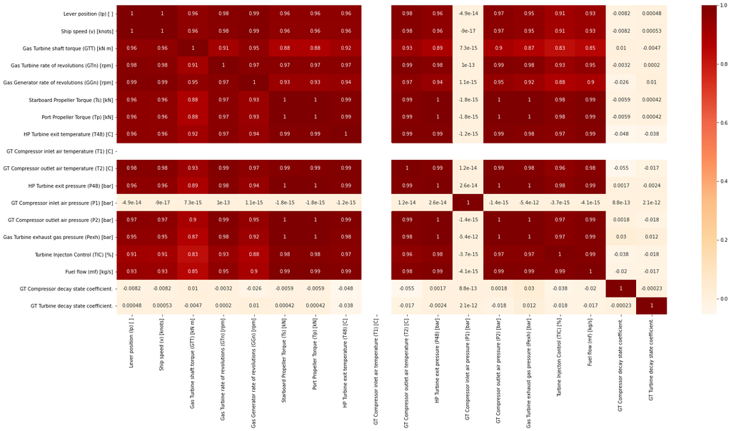

```python
plt.figure(figsize=(26, 12))
sns.heatmap(data.corr(),cmap="OrRd",annot=True)
plt.show()
```

### Almost all the columns are correlated to each other

Using PCA to remove correlation

```python
#Scalling the dataset

from sklearn.preprocessing import StandardScaler,scale
#we create an object of the class StandardScaler
sc = StandardScaler()

col_to_scale = NetF
data[col_to_scale] = sc.fit_transform(data[col_to_scale])
data.head()
```

|  | Lever position (lp) [ ] | Ship speed (v) [knots] | Gas Turbine shaft torque (GTT) [kN m] | Gas Turbine rate of revolutions (GTn) [rpm] | Gas Generator rate of revolutions (GGn) [rpm] | Starboard Propeller Torque (Ts) [kN] | Port Propeller Torque (Tp) [kN] | HP Turbine exit temperature (T48) [C] | GT Compressor inlet air temperature (T1) [C] | GT Compressor outlet air temperature (T2) [C] | HP Turbine exit pressure (P48) [bar] | GT Compressor inlet air pressure (P1) [bar] | GT Compressor outlet air pressure (P2) [bar] | Gas Turbine exhaust gas pressure (Pexh) [bar] | Turbine Injecton Control (TIC) [%] | Fuel flow (mf) [kg/s] | GT Compressor decay state coefficient. | GT Turbine decay state coefficient. |
| --- | --- | --- | --- | --- | --- | --- | --- | --- | --- | --- | --- | --- | --- | --- | --- | --- | --- | --- |
| 0 | 1.580104 | 1.555172 | 1.322492 | 1.634703 | 1.427819 | 2.094263 | 2.094263 | 2.035363 | 0.0 | 1.854638 | 2.011543 | 1.0 | 1.992931 | 1.986417 | 2.210993 | 2.237920 | -0.141251 | -1.259372 |
| 1 | 0.386541 | 0.389787 | 0.499220 | 0.401054 | 0.533560 | 0.096918 | 0.096918 | 0.240797 | 0.0 | 0.268663 | 0.155736 | 1.0 | 0.217219 | 0.054538 | 0.040334 | 0.047649 | 1.353502 | -1.659277 |
| 2 | -0.771120 | -0.775598 | -0.668301 | -1.045552 | -1.053655 | -0.833116 | -0.833116 | -0.843822 | 0.0 | -0.904644 | -0.886478 | 1.0 | -0.887217 | -0.911402 | -0.819509 | -0.820531 | 0.334352 | -1.259372 |
| 3 | -0.771120 | -0.775598 | -0.668101 | -1.045533 | -1.010633 | -0.833011 | -0.833011 | -0.954587 | 0.0 | -0.960212 | -0.888329 | 1.0 | -0.916746 | -0.814808 | -0.850569 | -0.852246 | 0.606126 | 1.673265 |
| 4 | 0.386541 | 0.389787 | 0.499236 | 0.401054 | 0.535407 | 0.096968 | 0.096968 | 0.199848 | 0.0 | 0.243393 | 0.155736 | 1.0 | 0.205182 | 0.151132 | 0.023152 | 0.029809 | 1.557332 | -0.992768 |

**PCA**  
Choosing 5 features

```python
data_nottarget = data.loc[:, data.columns != 'GT Compressor decay state coefficient.']
```

```python
from sklearn.decomposition import PCA
pca = PCA(n_components = 5)
pca.fit(data_nottarget.values)
```

```
PCA(n_components=5)
```

```python
data_nottarget = pca.transform(data_nottarget)
```

```python
data_nottarget = pd.DataFrame(data = data_nottarget
             , columns = ['PCA1', 'PCA2','PCA3','PCA5','PCA6'])
```

```python
data_pca = pd.concat([data_nottarget,data.loc[:, data.columns == 'GT Compressor decay state coefficient.']],axis = 1)
```

**PCA formed dataset**

```python
data_pca.head()
```

|  | PCA1 | PCA2 | PCA3 | PCA5 | PCA6 | GT Compressor decay state coefficient. |
| --- | --- | --- | --- | --- | --- | --- |
| 0 | 6.971965 | 1.274341 | 0.942096 | -0.197390 | -0.032727 | -0.141251 |
| 1 | 0.913716 | 1.642842 | -0.640136 | 0.137235 | 0.014403 | 1.353502 |
| 2 | -3.221326 | 1.268911 | -0.040687 | -0.213706 | -0.081844 | 0.334352 |
| 3 | -3.259821 | -1.667534 | 0.001809 | -0.224072 | -0.079056 | 0.606126 |
| 4 | 0.908470 | 0.973292 | -0.620046 | 0.152456 | 0.026738 | 1.557332 |

```python
data_pca.dropna(inplace = True)
```

**As you can see below, There's no correlation between features of the formed PCA dataset**

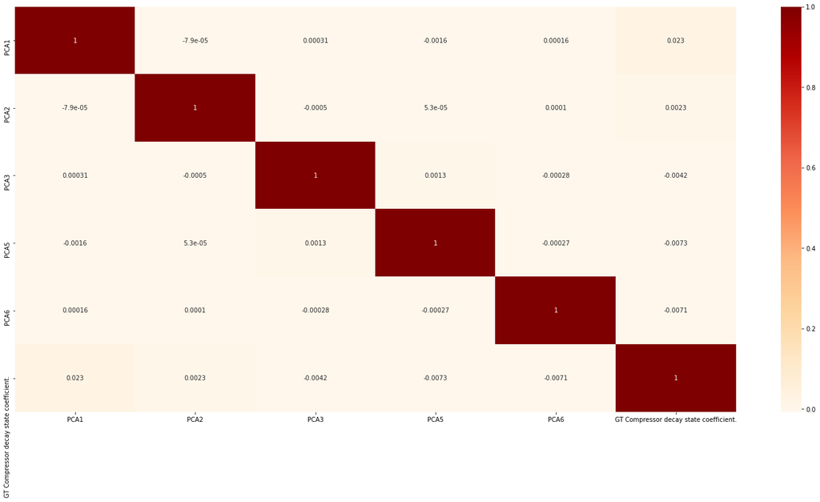

```python
plt.figure(figsize=(26, 12))
sns.heatmap(data_pca.corr(),cmap="OrRd",annot=True)
plt.show()
```

### Splitting and Model Building

```python
from sklearn.model_selection import train_test_split
data_train, data_test = train_test_split(data_pca, train_size = 0.8, test_size = 0.2, random_state = 0 )
```

```python
y_train = data_train.loc[:,data_train.columns == 'GT Compressor decay state coefficient.']
X_train = data_train.loc[:, data_train.columns != 'GT Compressor decay state coefficient.']
```

```python
y_test = data_test.loc[:,data_test.columns == 'GT Compressor decay state coefficient.']
X_test = data_test.loc[:, data_test.columns != 'GT Compressor decay state coefficient.']
```

```python
X_train.columns
```

```
Index(['PCA1', 'PCA2', 'PCA3', 'PCA5', 'PCA6'], dtype='object')
```

```python
X_train.shape
```

```
(7948, 5)
```

```python
y_train.head()
```

|  | GT Compressor decay state coefficient. |
| --- | --- |
| 2085 | 1.557332 |
| 1048 | -0.413024 |
| 418 | -0.684798 |
| 1033 | 1.625276 |
| 2253 | -0.480968 |

**Linear Model**

```python
# Making predictions
import statsmodels.api as sm

X_train_new = sm.add_constant(X_train)
lm = sm.OLS(y_train,X_train_new).fit()

print(lm.summary())
```

```
                                      OLS Regression Results
==================================================================================================
Dep. Variable:     GT Compressor decay state coefficient.   R-squared:                       0.000
Model:                                                OLS   Adj. R-squared:                 -0.000
Method:                                     Least Squares   F-statistic:                    0.6951
Date:                                    Tue, 17 Nov 2020   Prob (F-statistic):              0.627
Time:                                            09:26:54   Log-Likelihood:                -11267.
No. Observations:                                    7948   AIC:                         2.255e+04
Df Residuals:                                        7942   BIC:                         2.259e+04
Df Model:                                               5
Covariance Type:                                nonrobust
==============================================================================
                 coef    std err          t      P>|t|      [0.025      0.975]
------------------------------------------------------------------------------
const          0.0078      0.011      0.695      0.487      -0.014       0.030
PCA1           0.0049      0.003      1.612      0.107      -0.001       0.011
PCA2           0.0007      0.011      0.065      0.948      -0.021       0.023
PCA3          -0.0015      0.018     -0.079      0.937      -0.038       0.035
PCA5          -0.0056      0.041     -0.137      0.891      -0.086       0.075
PCA6          -0.0631      0.068     -0.926      0.354      -0.197       0.070
==============================================================================
Omnibus:                     6615.952   Durbin-Watson:                   2.025
Prob(Omnibus):                  0.000   Jarque-Bera (JB):              473.507
Skew:                          -0.002   Prob(JB):                    1.51e-103
Kurtosis:                       1.804   Cond. No.                         22.4
==============================================================================

Warnings:
[1] Standard Errors assume that the covariance matrix of the errors is correctly specified.
```

## Conclusion from this model

1) R sqaured is 0, which means this model does not explain any variablity in the dataset  
2) P-value of all the features is more than 0.05 which makes them insignificant, making this model absolutely useless  
3) Using of PCA or removing features, even the most correlated ones in this dataset, affects how much variance can our model explain

### Scrapping PCA and Working on our original dataset

```python
from sklearn.model_selection import train_test_split
data_train, data_test = train_test_split(data, train_size = 0.8, test_size = 0.2, random_state = 0 )
```

First model for **GT Compressor decay state coefficient.**

```python
y_train = data_train.loc[:,data_train.columns == 'GT Compressor decay state coefficient.']
X_train = data_train.loc[:, data_train.columns != 'GT Compressor decay state coefficient.']
```

```python
y_test = data_test.loc[:,data_test.columns == 'GT Compressor decay state coefficient.']
X_test = data_test.loc[:, data_test.columns != 'GT Compressor decay state coefficient.']
```

#### Linear regression

```python
# Linear regression for our original non-pca dataset with correlated features
# Making predictions
import statsmodels.api as sm

X_train_new = sm.add_constant(X_train)
lm = sm.OLS(y_train,X_train_new).fit()

print(lm.summary())
```

```
                                      OLS Regression Results
==================================================================================================
Dep. Variable:     GT Compressor decay state coefficient.   R-squared:                       0.887
Model:                                                OLS   Adj. R-squared:                  0.887
Method:                                     Least Squares   F-statistic:                     4479.
Date:                                    Tue, 17 Nov 2020   Prob (F-statistic):               0.00
Time:                                            09:26:54   Log-Likelihood:                -2589.6
No. Observations:                                    7974   AIC:                             5209.
Df Residuals:                                        7959   BIC:                             5314.
Df Model:                                              14
Covariance Type:                                nonrobust
=================================================================================================================
                                                    coef    std err          t      P>|t|      [0.025      0.975]
-----------------------------------------------------------------------------------------------------------------
Lever position (lp) [ ]                          57.4801      0.681     84.389      0.000      56.145      58.815
Ship speed (v) [knots]                          -49.4555      0.623    -79.438      0.000     -50.676     -48.235
Gas Turbine shaft torque (GTT) [kN m]             1.1694      0.042     27.750      0.000       1.087       1.252
Gas Turbine rate of revolutions (GTn) [rpm]       1.7892      0.113     15.777      0.000       1.567       2.011
Gas Generator rate of revolutions (GGn) [rpm]     3.5821      0.062     57.539      0.000       3.460       3.704
Starboard Propeller Torque (Ts) [kN]            -11.2438      0.149    -75.679      0.000     -11.535     -10.953
Port Propeller Torque (Tp) [kN]                 -11.2438      0.149    -75.679      0.000     -11.535     -10.953
HP Turbine exit temperature (T48) [C]            -4.2012      0.181    -23.224      0.000      -4.556      -3.847
GT Compressor inlet air temperature (T1) [C]  -1.348e-13   1.46e-15    -92.319      0.000   -1.38e-13   -1.32e-13
GT Compressor outlet air temperature (T2) [C]   -16.5486      0.134   -123.404      0.000     -16.811     -16.286
HP Turbine exit pressure (P48) [bar]             28.2340      0.657     42.972      0.000      26.946      29.522
GT Compressor inlet air pressure (P1) [bar]      -0.0003      0.004     -0.074      0.941      -0.008       0.007
GT Compressor outlet air pressure (P2) [bar]    -16.6344      0.509    -32.668      0.000     -17.633     -15.636
Gas Turbine exhaust gas pressure (Pexh) [bar]     2.3421      0.134     17.488      0.000       2.080       2.605
Turbine Injecton Control (TIC) [%]               -1.2905      0.031    -41.731      0.000      -1.351      -1.230
Fuel flow (mf) [kg/s]                            16.4497      0.370     44.513      0.000      15.725      17.174
GT Turbine decay state coefficient.              -0.4677      0.009    -52.441      0.000      -0.485      -0.450
==============================================================================
Omnibus:                        9.709   Durbin-Watson:                   1.990
Prob(Omnibus):                  0.008   Jarque-Bera (JB):               10.993
Skew:                          -0.025   Prob(JB):                      0.00410
Kurtosis:                       3.175   Cond. No.                     1.27e+18
==============================================================================

Warnings:
[1] Standard Errors assume that the covariance matrix of the errors is correctly specified.
[2] The smallest eigenvalue is 6.62e-32. This might indicate that there are
strong multicollinearity problems or that the design matrix is singular.
```

```python
#P-value of 0.9 makes this feature insignificant
X_train_new.drop(["GT Compressor inlet air pressure (P1) [bar]"], axis = 1, inplace = True)
lm = sm.OLS(y_train,X_train_new).fit()
print(lm.summary())
```

```
                                           OLS Regression Results
===========================================================================================================
Dep. Variable:     GT Compressor decay state coefficient.   R-squared (uncentered):                   0.887
Model:                                                OLS   Adj. R-squared (uncentered):              0.887
Method:                                     Least Squares   F-statistic:                              4479.
Date:                                    Tue, 17 Nov 2020   Prob (F-statistic):                        0.00
Time:                                            09:26:54   Log-Likelihood:                         -2589.6
No. Observations:                                    7974   AIC:                                      5207.
Df Residuals:                                        7960   BIC:                                      5305.
Df Model:                                              14
Covariance Type:                                nonrobust
=================================================================================================================
                                                    coef    std err          t      P>|t|      [0.025      0.975]
-----------------------------------------------------------------------------------------------------------------
Lever position (lp) [ ]                          57.4804      0.681     84.397      0.000      56.145      58.816
Ship speed (v) [knots]                          -49.4558      0.623    -79.446      0.000     -50.676     -48.236
Gas Turbine shaft torque (GTT) [kN m]             1.1695      0.042     27.752      0.000       1.087       1.252
Gas Turbine rate of revolutions (GTn) [rpm]       1.7893      0.113     15.779      0.000       1.567       2.012
Gas Generator rate of revolutions (GGn) [rpm]     3.5820      0.062     57.542      0.000       3.460       3.704
Starboard Propeller Torque (Ts) [kN]            -11.2437      0.149    -75.685      0.000     -11.535     -10.952
Port Propeller Torque (Tp) [kN]                 -11.2437      0.149    -75.685      0.000     -11.535     -10.952
HP Turbine exit temperature (T48) [C]            -4.2012      0.181    -23.226      0.000      -4.556      -3.847
GT Compressor inlet air temperature (T1) [C]   7.093e-14   7.37e-16     96.225      0.000    6.95e-14    7.24e-14
GT Compressor outlet air temperature (T2) [C]   -16.5486      0.134   -123.413      0.000     -16.811     -16.286
HP Turbine exit pressure (P48) [bar]             28.2336      0.657     42.975      0.000      26.946      29.521
GT Compressor outlet air pressure (P2) [bar]    -16.6343      0.509    -32.670      0.000     -17.632     -15.636
Gas Turbine exhaust gas pressure (Pexh) [bar]     2.3422      0.134     17.490      0.000       2.080       2.605
Turbine Injecton Control (TIC) [%]               -1.2905      0.031    -41.735      0.000      -1.351      -1.230
Fuel flow (mf) [kg/s]                            16.4497      0.370     44.516      0.000      15.725      17.174
GT Turbine decay state coefficient.              -0.4677      0.009    -52.444      0.000      -0.485      -0.450
==============================================================================
Omnibus:                        9.709   Durbin-Watson:                   1.990
Prob(Omnibus):                  0.008   Jarque-Bera (JB):               10.992
Skew:                          -0.025   Prob(JB):                      0.00410
Kurtosis:                       3.175   Cond. No.                     1.10e+20
==============================================================================

Warnings:
[1] Standard Errors assume that the covariance matrix of the errors is correctly specified.
[2] The smallest eigenvalue is 8.8e-36. This might indicate that there are
strong multicollinearity problems or that the design matrix is singular.
```

#### SVM regressor

```python
from sklearn.svm import SVR
regressor = SVR(kernel='rbf')
regressor.fit(X_train,y_train)
y_pred = regressor.predict(X_test)
```

```python
from sklearn.metrics import r2_score
r2_score(y_test, y_pred)

#R2 square
```

```
0.9484493434867681
```

#### Random Forest regressor

10 estimators

```python
from sklearn.ensemble import RandomForestRegressor
#Random forest
reg_rf = RandomForestRegressor(n_estimators=10, random_state=0)
reg_rf.fit(X_train, y_train)
y_pred = reg_rf.predict(X_test)

from sklearn.metrics import r2_score
r2_score(y_test, y_pred)

#Increasing the estimators doesn't increase the r2 score that much so 10 estimators are optimal
```

```
0.9967080522311376
```

```python
from sklearn import metrics

print('Mean Absolute Error:', metrics.mean_absolute_error(y_test, y_pred))
print('Mean Squared Error:', metrics.mean_squared_error(y_test, y_pred))
print('Root Mean Squared Error:', np.sqrt(metrics.mean_squared_error(y_test, y_pred)))
```

```
Mean Absolute Error: 0.038466010963345336
Mean Squared Error: 0.00335399151020388
Root Mean Squared Error: 0.05791365564531288
```

```python
resid = y_test['GT Compressor decay state coefficient.'] - y_pred
# Durbin watson test to check for autocorrelation in error terms, as its close to 2
# That means our error terms are independent of each other

from statsmodels.stats.stattools import durbin_watson
print(durbin_watson(resid))
```

```
1.9867540983606584
```

**Neural Networks**

### Architecture for our ANN

```python
from keras.models import Sequential
from keras.layers import Dense
#create model


def Model_ANN(loss_func):
    model = Sequential()
    #input layer
    model.add(Dense(input_dim = 17, units = 256, kernel_initializer='normal', activation='relu'))
    #1 Dense Layers
    model.add(Dense(64,activation = 'relu', kernel_initializer='normal',kernel_regularizer='l2'))
    model.add(Dense(64,activation = 'relu', kernel_initializer='normal'))
    #Output layer
    model.add(Dense(1, kernel_initializer='normal' ))
    model.compile(optimizer='adam', loss=loss_func)
    return model
```

```python
model = Model_ANN(loss_func = 'mean_squared_error')
model.fit(X_train, y_train, validation_data=(X_test, y_test), epochs=40, batch_size = 10)
```

```
<tensorflow.python.keras.callbacks.History at 0x17d6a806828>
```

```python
y_pred = model.predict(X_test)
#R square score to check our model
from sklearn.metrics import r2_score
r2_score(y_test, y_pred)
```

```
0.9905325434092344
```

```python
print('Mean Absolute Error:', metrics.mean_absolute_error(y_test, y_pred))
print('Mean Squared Error:', metrics.mean_squared_error(y_test, y_pred))
print('Root Mean Squared Error:', np.sqrt(metrics.mean_squared_error(y_test, y_pred)))
```

```
Mean Absolute Error: 0.07818620787750304
Mean Squared Error: 0.009645890900518178
Root Mean Squared Error: 0.09821349652933745
```

```python
resid = y_test - y_pred
# Durbin watson test to check for autocorrelation in error terms, as its close to 2
# That means our error terms are independent of each other

from statsmodels.stats.stattools import durbin_watson
print(durbin_watson(resid))
```

```
[1.83483058]
```

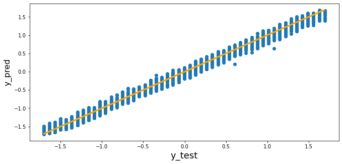

```python
fig = plt.figure(figsize=(11,5))
plt.scatter(y_test,y_pred)
plt.xlabel('y_test', fontsize=18)
plt.ylabel('y_pred', fontsize=16)

#Regression Line function
f = lambda x: x

# x values of line to plot
x = np.array(y_test)

# plot fit
plt.plot(x,f(x),lw=2.5, c="orange")
```

**Final model is Random forest regressor i.e reg_rf()**

### Conclusions

1) Our ANN model gives a good R2 square value, but as none of the correlated features were removed, there's good chance that the model is overfitting -

- Getting more data to remove correlation will help solve this problem

3) Using l2 regularisation to remove overfitting but the model still might have overfitted

4) After testing, if the model gives bad score, further steps to improve include -

- Get more data to remove correlation
- Using multiple models for our prediction

5) Final Model selected is the Random Forest regression Model because -

- Computationally less expensive than Neural network but almost same R-squared value
- Lowest mean-squared and root-mean-squared error
- Is not affected by correlation as much
- Discernable model

### Model for GT Turbine decay state coefficient

```python
#Splitting it based on that cofficient
y_train = data_train.loc[:,data_train.columns == 'GT Turbine decay state coefficient.']
X_train = data_train.loc[:, data_train.columns != 'GT Turbine decay state coefficient.']
y_test = data_test.loc[:,data_test.columns == 'GT Turbine decay state coefficient.']
X_test = data_test.loc[:, data_test.columns != 'GT Turbine decay state coefficient.']
```

```python
X_train.head()
```

|  | Lever position (lp) [ ] | Ship speed (v) [knots] | Gas Turbine shaft torque (GTT) [kN m] | Gas Turbine rate of revolutions (GTn) [rpm] | Gas Generator rate of revolutions (GGn) [rpm] | Starboard Propeller Torque (Ts) [kN] | Port Propeller Torque (Tp) [kN] | HP Turbine exit temperature (T48) [C] | GT Compressor inlet air temperature (T1) [C] | GT Compressor outlet air temperature (T2) [C] | HP Turbine exit pressure (P48) [bar] | GT Compressor inlet air pressure (P1) [bar] | GT Compressor outlet air pressure (P2) [bar] | Gas Turbine exhaust gas pressure (Pexh) [bar] | Turbine Injecton Control (TIC) [%] | Fuel flow (mf) [kg/s] | GT Compressor decay state coefficient. |
| --- | --- | --- | --- | --- | --- | --- | --- | --- | --- | --- | --- | --- | --- | --- | --- | --- | --- |
| 1367 | 1.162261 | 1.166710 | 0.995183 | 1.229682 | 1.025966 | 1.058956 | 1.058956 | 1.224325 | 0.0 | 1.295216 | 1.136861 | 1.0 | 1.189243 | 1.117071 | 1.107529 | 1.123954 | -1.364231 |
| 9746 | 1.162261 | 1.166710 | 0.995134 | 1.229632 | 1.024895 | 1.058240 | 1.058240 | 1.061160 | 0.0 | 1.193047 | 1.132233 | 1.0 | 1.127927 | 1.117071 | 1.018314 | 1.034757 | -0.413024 |
| 5684 | 0.758168 | 0.778249 | 0.747704 | 0.825236 | 0.863243 | 0.527905 | 0.527905 | 0.535271 | 0.0 | 0.659917 | 0.561144 | 1.0 | 0.576650 | 0.537507 | 0.402014 | 0.412364 | -1.160401 |
| 3691 | -1.537292 | -1.552522 | -0.844037 | -1.132931 | -1.391259 | -1.098939 | -1.098939 | -0.547744 | 0.0 | -1.026238 | -0.957748 | 1.0 | -0.979754 | -1.007996 | -0.530912 | -0.693674 | -0.005364 |
| 3385 | 1.580104 | 1.555172 | 1.322563 | 1.634717 | 1.442343 | 2.095495 | 2.095495 | 2.075251 | 0.0 | 1.893889 | 1.993957 | 1.0 | 1.954938 | 1.986417 | 2.220595 | 2.247831 | -0.820684 |

**GT Turbine decay state coefficient minimizing ‘rmse’ loss function**  
Root mean squared error function

```python
from keras import backend as K
def root_mean_squared_error(y_act, y_pred):
    return K.sqrt(K.mean(K.square(y_pred - y_act), axis=-1))
```

```python
#Model
#Input layer (17 dims)
# Two dense layers(nodes = 64)
#Output Layer

model1 = Sequential()
#input layer
model1.add(Dense(input_dim = 17, units = 256, kernel_initializer='normal', activation='relu'))
#1 Dense Layers
model1.add(Dense(64,activation = 'relu', kernel_initializer='normal'))
model1.add(Dense(64,activation = 'relu', kernel_initializer='normal'))
#Output layer
model1.add(Dense(1, kernel_initializer='normal' ))
model1.compile(optimizer='adam', loss=root_mean_squared_error)
model1.fit(X_train, y_train, validation_data=(X_test, y_test), epochs=50, batch_size = 10)
```

```
<tensorflow.python.keras.callbacks.History at 0x17d5d975ac8>
```

```python
#Predicting
y_pred = model1.predict(X_test)
#R2 score
from sklearn.metrics import r2_score
r2_score(y_test, y_pred)
```

```
0.9461462993224528
```

```python
#Residual
resid = y_test - y_pred
#Durbin wayson test for autocorrelation among error terms, close to 2, so error terms
# are almost indepedent of each other
from statsmodels.stats.stattools import durbin_watson
print(durbin_watson(resid))
```

```
[1.90703838]
```

Conclusion from the model used for compressor cofficient holds here as well. Reiterating them -

### Conclusions

- Getting more data to remove correlation will help solve this problem

4) After testing, if the model gives bad score, further steps to improve include -

- Get more data to remove correlation
- Using multiple models for our prediction

5) Model - ANN, condition - minimising 'rmse'